# 8.4 Exercises

```r
# load all libraries needed for these exercises
library(MASS)
library(randomForest)
library(tree)
library(ISLR)
library(gbm)
library(leaps)
library(class)
library(datasets)
```

# Exercise 7

In the lab, we applied random forests to the **Boston** data using **mtry=6** and using **ntree=25** and **ntree=500**. Create a plot displaying the test error resulting from random forests on this data set for a more comprehensive range of values for **mtry** and **ntree**. You can model your plot after Figure 8.10. Describe the results obtained.

```r
# Boston data set is in the MASS library
library(MASS)

# create a training set index with half the data
set.seed(1)
train = sample(1:nrow(Boston), size = nrow(Boston)/2, replace = FALSE)

# per Figure 8.10, we will test 1 to 500 trees, with m = p, m = p/2, and m = sqrt(p)
ntrees = 1:500
test.mse = data.frame(p = rep(NaN, length(ntrees)), p2 = rep(NaN, length(ntrees)), sqrt.p = rep(NaN, length(ntrees)))

# one of the columns is the response and therefore not a valid predictor
p = ncol(Boston) - 1
columns = c('p', 'p2', 'sqrt.p')
m.values = c(p, p/2, sqrt(p))

# Load the randomForest() function from the randomForest library
library(randomForest)

getTestMSE = function(ntree, mtry){
  rf.model = randomForest(medv ~ ., data = Boston, subset = train, mtry = mtry, ntree = ntree)
  rf.pred = predict(rf.model, newdata = Boston[-train,])
  return(mean((rf.pred - Boston[-train, 'medv'])^2))
}

# loop through different numbers of trees and find the three test errors
# record the minimum test error
min.error = Inf
for (ntree in ntrees){
  for (i in 1:length(m.values)){
    this.col = columns[i]
    m = m.values[i]
    this.error = getTestMSE(ntree, m)
    test.mse[ntree, this.col] = this.error
    if (this.error < min.error){
      min.error = this.error
      min.ntree = ntree
      min.m = m
    }
  }
}
```

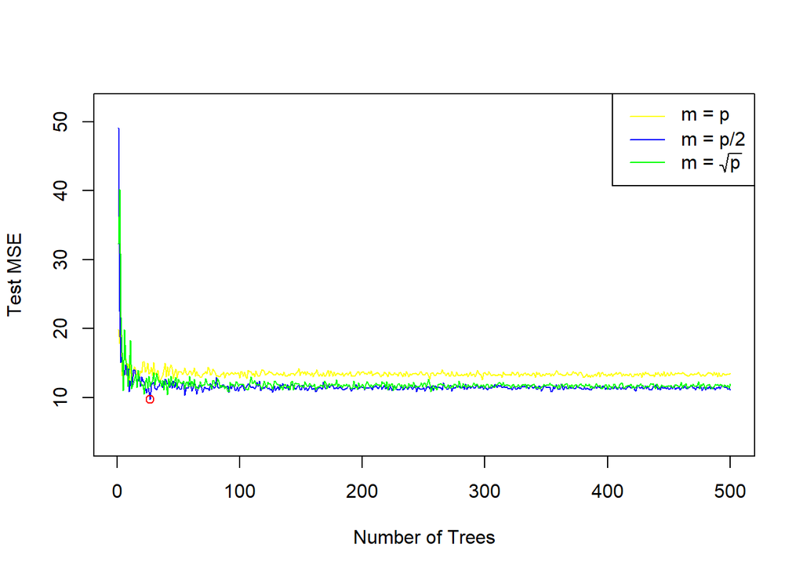

```r
# Bound the y-axis limits of the plot to avoid cutting off the lines
y.min = min.m - 3
y.max = max(test.mse) + 3

# plot test errors in the same fasion as Figure 8.10
plot(ntrees, test.mse$p, xlab = 'Number of Trees', ylab = 'Test MSE', col = 'yellow', type = 'l', ylim = c(y.min, y.max))
lines(ntrees, test.mse$p2, col = 'blue')
lines(ntrees, test.mse$sqrt.p, col = 'green')
points(min.ntree, min.error, col = 'red')
legend('topright', col = c('yellow', 'blue', 'green'), legend = c('m = p', 'm = p/2', expression(paste('m = ', sqrt(p)))), lty = 1)
```

*In this plot, it’s hard to see much of a difference between the different values of* m, *but we can clearly see that additional trees after about* 50 *are not providing additional test accuracy.*

```r
# print the minimum error and the associated ntree and mtry
min.error
```

```
## [1] 9.782963
```

```r
min.ntree
```

```
## [1] 27
```

```r
min.m
```

```
## [1] 6.5
```

*The lowest test MSE resulted from aggregating* 27 *trees and considering* p/2 *predictors at each branch. Let’s zoom in our plot around here to get a better look at what’s going on.*

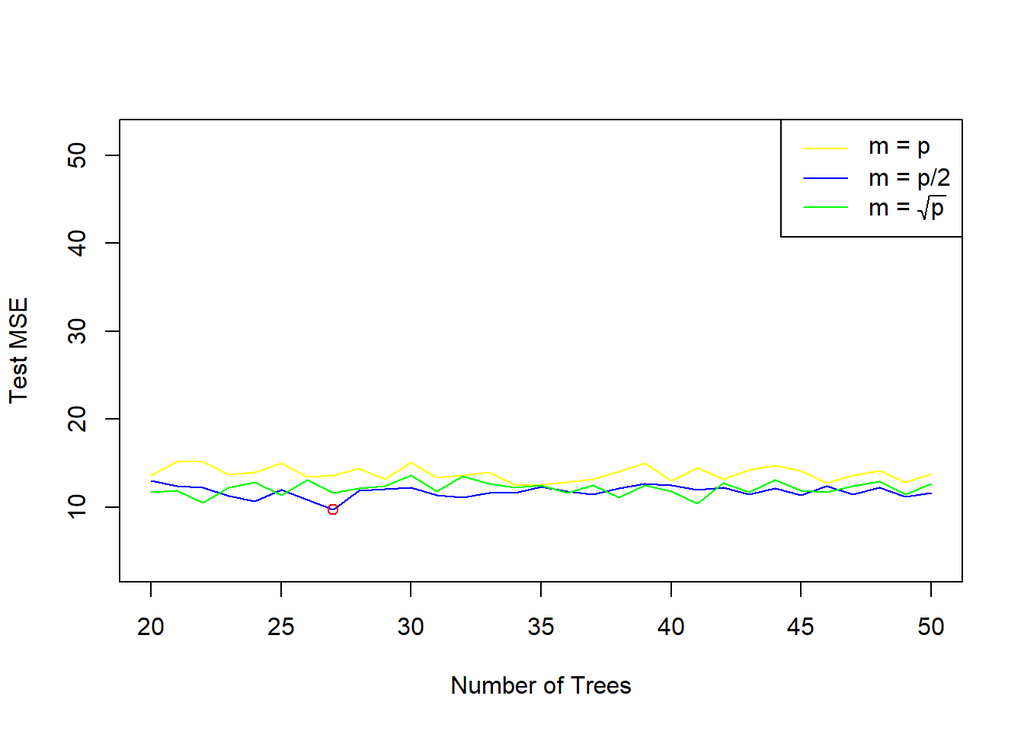

```r
zoom.index = 20:50
plot(zoom.index, test.mse[zoom.index, 'p'], xlab = 'Number of Trees', ylab = 'Test MSE', col = 'yellow', type = 'l', ylim = c(y.min, y.max))
lines(zoom.index, test.mse[zoom.index, 'p2'], col = 'blue')
lines(zoom.index, test.mse[zoom.index, 'sqrt.p'], col = 'green')
points(min.ntree, min.error, col = 'red')
legend('topright', col = c('yellow', 'blue', 'green'), legend = c('m = p', 'm = p/2', expression(paste('m = ', sqrt(p)))), lty = 1)
```

*So here we can see that in this range of numbers of trees, there really isn’t much difference between the different values for* m *or the number of trees being used. In fact, our selection of this particular pair of* m *and* ntrees *seems like it could just be a bit of noise in the variations in test error. In conclusion, for this data set, it seems like the only important thing is to use a sufficient number of trees in the bagging and/or random forests.* 25 *or more trees seems sufficient based on this data.*

# Exercise 8

In the lab, a classification tree was applied to the **Carseats** data set after converting **Sales** into a qualitative response variable. Now we will seek to predict **Sales** using regression trees and related approaches, treating the response as a quantitative variable.

```r
# the Carseats data set resides in the ISLR library
library(ISLR)
```

1. Split the data set into a training set and a test set.

```r
# we'll go 50-50 on training and test data
train = sample(nrow(Carseats), nrow(Carseats)/2, replace = F)
```

2. Fit a regression tree to the training set. Plot the tree and interpret the results. What test MSE do you obtain?

```r
# the tree() function is in the tree library
library(tree)

# Make a reusable function for getting the test mse on this data set
getTestMSE = function(model){
  model.pred = predict(model, newdata = Carseats[-train,])
  return(mean((model.pred - Carseats[-train, 'Sales'])^2))
}

tree.model = tree(Sales ~ ., data = Carseats, subset = train)
tree.mse = getTestMSE(tree.model)
tree.mse
```

```
## [1] 4.730486
```

*A simple regression tree yields a test MSE of* 4.73.

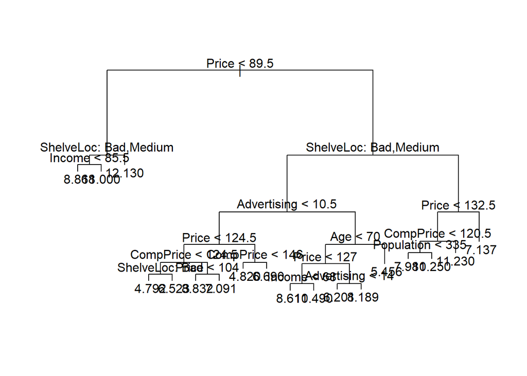

```r
plot(tree.model)
text(tree.model, pretty = 0)
```

*In this tree, the most important predictors are considered to be* **Price** *and* **ShelveLoc**.

3. Use cross-validation in order to determine the optimal level of tree complexity. Does pruning the tree improve the test MSE?

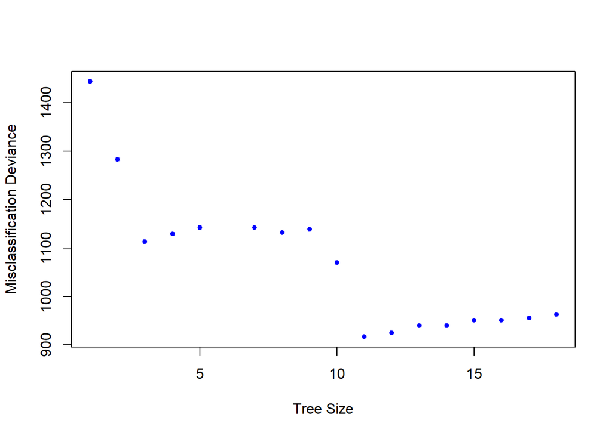

```r
set.seed(4)
cv.carseats = cv.tree(tree.model)
plot(cv.carseats$size, cv.carseats$dev, pch = 20, col = 'blue', xlab = 'Tree Size', ylab = 'Misclassification Deviance')
```

```r
best.size = cv.carseats$size[which.min(cv.carseats$dev)]
best.size
```

```
## [1] 11
```

```r
prune.model = prune.tree(tree.model, best = best.size)
getTestMSE(prune.model)
```

```
## [1] 5.081844
```

*The pruned model with 11 terminal nodes does not yield a lower test MSE. Note, I played with the seed value I set before taking the CV so that I would get a smaller tree. Seeds 1-3 actually did not result in a smaller tree.*

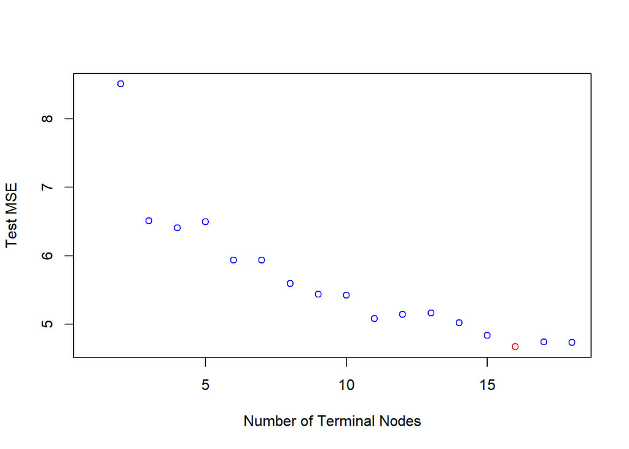

```r
# Let's plot the test MSE of different sizes to see if any of them yield a smaller test MSE
max.size = length(cv.carseats$size) + 1
test.mse = rep(NA, max.size)
for (this.size in 2:max.size){
  test.mse[this.size] = getTestMSE(prune.tree(tree.model, best = this.size))
}
best.size = which.min(test.mse)
plot(test.mse, xlab = "Number of Terminal Nodes", ylab = "Test MSE", col = "blue")
points(best.size, test.mse[best.size], col = "red")
```

```r
best.size
```

```
## [1] 16
```

```r
test.mse[best.size]
```

```
## [1] 4.670888
```

*The pruned tree with only 16 terminal nodes has a slightly lower test MSE than the fully grown tree in this case.*

4. Use the bagging approach in order to analyze this data. What test MSE do you obtain? Use the **importance()** function to determine which variables are most important.

```r
set.seed(1)

# We need to set mtry equal to the number of predictors in the model in order to perform bagging instead of random forests
p = ncol(Carseats) - 1
bag.carseats = randomForest(Sales ~ ., data = Carseats, subset = train, mtry = p, importance = TRUE)
bag.mse = getTestMSE(bag.carseats)
bag.mse
```

```
## [1] 3.158778
```

*Wow! It’s a huge performance improvement. The test MSE obtained from baggging is much smaller than the test MSE from the pruned tree.*

```r
importance(bag.carseats)
```

```
##                 %IncMSE IncNodePurity
## CompPrice   20.77899423    130.943589
## Income       7.25172186     80.581428
## Advertising 21.54915861    185.810892
## Population   0.41671466     55.003974
## Price       54.13927377    431.922698
## ShelveLoc   41.38863827    248.451451
## Age         12.63004181    111.973059
## Education    3.32618162     35.487637
## Urban        0.01734356      6.507844
## US           2.33948140      7.191645
```

*In terms of training MSE, the bagging model lists* **Price** *and* **ShelveLoc** *as the two most important predictors.* **Advertising** *and* **CompPrice** *are also considered important, but they don’t impact the training MSE as much. Recall that the fully grown tree also considered* **Price** *and* **ShelveLoc** *to be the most important factors in predicting* **Sales**.

5. Use random forests to analyze this data. What test MSE do you obtain? Use the **importance()** function to determine which variables are most important. Describe the effect of *m*, the number of variables considered at each split, on the error rate obtained.

```r
set.seed(1)

# First we'll use m = p/2
m = p/2
rf.carseats = randomForest(Sales ~ ., data = Carseats, subset = train, mtry = m, importance = TRUE)
rf.mse = getTestMSE(rf.carseats)
rf.mse
```

```
## [1] 3.475288
```

*Random forests with* $m = p/2$ *doesn’t yield quite as low a test MSE as bagging, but it is still a significant improvement over the full tree and pruned tree test MSE.*

```r
importance(rf.carseats)
```

```
##                %IncMSE IncNodePurity
## CompPrice   14.1636754    119.055120
## Income       4.4456966     93.357926
## Advertising 19.3332935    169.700848
## Population  -0.9103591     77.596018
## Price       43.1857963    387.705189
## ShelveLoc   34.1445934    232.120164
## Age         10.4461913    118.779148
## Education    0.9741664     51.301962
## Urban        0.7789178      8.517634
## US           4.8030455     20.208178
```

*Nothing too different about the order of predictor importance. It may be worth noting that the predictors which were considered much more important in the bagging model are a bit closer in importance to the other predictors.*

```r
set.seed(1)

# Now we'll try m = sqrt(p)
m = sqrt(p)
rf.carseats = randomForest(Sales ~ ., data = Carseats, subset = train, mtry = m, importance = TRUE)
rf.mse = getTestMSE(rf.carseats)
rf.mse
```

```
## [1] 4.107447
```

*Random forests with* $m = \sqrt{p}$ *yields a test MSE similar to the pruned tree test MSE - not great.*

```r
importance(rf.carseats)
```

```
##                %IncMSE IncNodePurity
## CompPrice    9.8053219     111.37676
## Income       1.5185003     102.50976
## Advertising 16.4317019     156.84286
## Population   0.2753494     101.21260
## Price       36.0495211     336.83466
## ShelveLoc   29.1520438     196.30048
## Age          9.1381909     129.59990
## Education    3.6112924      68.37053
## Urban        0.1102256      11.87917
## US           6.6298204      36.73006
```

*The importance table yielded with* $m = \sqrt{p}$ *is similar to the one with* $m = p/2$ *with respect to predictor importance on training MSE. However, predictor importance has become even more “flat”.*

# Exercise 9

This problem involves the **OJ** data set, which is part of the **ISLR** package.

1. Create a training set containing a random sample of 800 observations and a test set containing the remaining observations.

```r
set.seed(1)
train = sample(nrow(OJ), 800)
```

2. Fit a tree to the training data, with **Purchase** as the response and the other variables as predictors. Use the **summary()** function to produce summary statistics about the tree, and describe the results obtained.

```r
tree.model = tree(Purchase ~ ., data = OJ, subset = train)
summary(tree.model)
```

```
##
## Classification tree:
## tree(formula = Purchase ~ ., data = OJ, subset = train)
## Variables actually used in tree construction:
## [1] "LoyalCH"       "PriceDiff"     "SpecialCH"     "ListPriceDiff"
## Number of terminal nodes:  8
## Residual mean deviance:  0.7305 = 578.6 / 792
## Misclassification error rate: 0.165 = 132 / 800
```

*The resulting tree has 8 terminal nodes and only uses 4 predictors from the data set, which has 17 available predictors to use. The training misclassification error rate was 0.165.*

3. Type in the name of the tree object in order to get a detailed text output. Pick one of the terminal nodes and interpret the information displayed.

```r
tree.model
```

```
## node), split, n, deviance, yval, (yprob)
##       * denotes terminal node
##
##  1) root 800 1064.00 CH ( 0.61750 0.38250 )
##    2) LoyalCH < 0.508643 350  409.30 MM ( 0.27143 0.72857 )
##      4) LoyalCH < 0.264232 166  122.10 MM ( 0.12048 0.87952 )
##        8) LoyalCH < 0.0356415 57   10.07 MM ( 0.01754 0.98246 ) *
##        9) LoyalCH > 0.0356415 109  100.90 MM ( 0.17431 0.82569 ) *
##      5) LoyalCH > 0.264232 184  248.80 MM ( 0.40761 0.59239 )
##       10) PriceDiff < 0.195 83   91.66 MM ( 0.24096 0.75904 )
##         20) SpecialCH < 0.5 70   60.89 MM ( 0.15714 0.84286 ) *
##         21) SpecialCH > 0.5 13   16.05 CH ( 0.69231 0.30769 ) *
##       11) PriceDiff > 0.195 101  139.20 CH ( 0.54455 0.45545 ) *
##    3) LoyalCH > 0.508643 450  318.10 CH ( 0.88667 0.11333 )
##      6) LoyalCH < 0.764572 172  188.90 CH ( 0.76163 0.23837 )
##       12) ListPriceDiff < 0.235 70   95.61 CH ( 0.57143 0.42857 ) *
##       13) ListPriceDiff > 0.235 102   69.76 CH ( 0.89216 0.10784 ) *
##      7) LoyalCH > 0.764572 278   86.14 CH ( 0.96403 0.03597 ) *
```

*Let’s look at terminal node (8). The predictor region defined by this terminal node encompasses 57 of the original 800 training observations, which is 7.125%. This region is defined by* **LoyalCH** < 0.0356415 *(the conditions for branches leading to this terminal node all happened to be checking for* **LoyalCH** *less than a certain value as well). The model predicts any observations meeting that criteria to have a response value of* **MM** *(indicating a purchase of Minute Maid orange juice). 98.246% of the training observations in this region had a response value of* **MM**.

4. Create a plot of the tree and interpret the results.

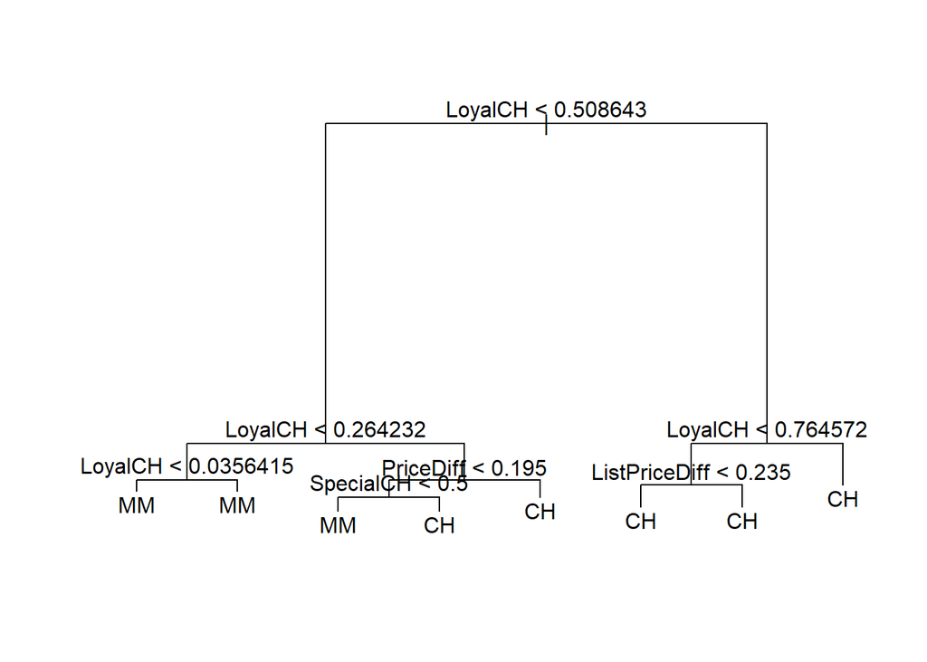

```r
plot(tree.model)
text(tree.model, pretty = 0)
```

*Again, we see that we have 8 terminal nodes, 3 of which correspond to a prediction of* **MM**. **LoyalCH** *is considered to be the most important predictor in determining* **Purchase**.

5. Predict the response on the test data and produce a confusion matrix comparing the test labels to the predicted test labels. What is the test error rate?

```r
tree.prob = predict(tree.model, newdata = OJ[-train,])
tree.predict = rep('MM', nrow(tree.prob))
tree.predict[tree.prob[, 'CH'] >= .5] = 'CH'
table(tree.predict, OJ[-train, 'Purchase'])
```

```
##
## tree.predict  CH  MM
##           CH 147  49
##           MM  12  62
```

```r
tree.testError = (12 + 62) / length(tree.predict)
tree.testError
```

```
## [1] 0.2740741
```

6. Apply the **cv.tree()** function to the training set in order to determine the optimal tree size.

```r
set.seed(1)
cv.model = cv.tree(tree.model, FUN = prune.misclass)
cv.model
```

```
## $size
## [1] 8 5 2 1
##
## $dev
## [1] 152 152 161 306
##
## $k
## [1]       -Inf   0.000000   4.666667 160.000000
##
## $method
## [1] "misclass"
##
## attr(,"class")
## [1] "prune"         "tree.sequence"
```

7. Produce a plot with tree size on the *x*-axis and cross-validated classification error rate on the *y*-axis.

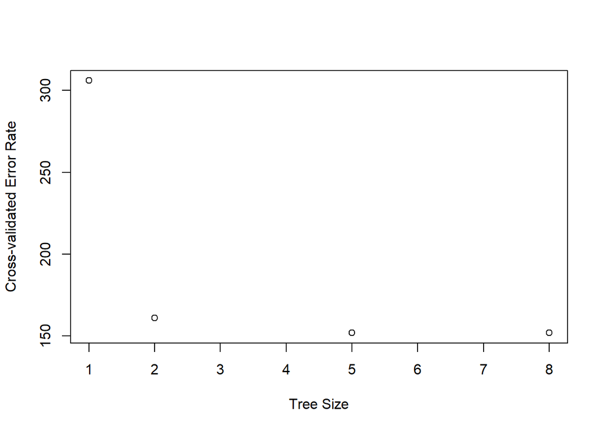

```r
plot(cv.model$size, cv.model$dev, xlab = "Tree Size", ylab = "Cross-validated Error Rate")
```

8. Which tree size corresponds to the lowest cross-validated classification error rate?

*Both 5 and 8 terminal nodes yield the lowest CV error rate. We’ll look at pruning the tree to 5 terminal nodes, since we already examined the full tree with 8 terminal nodes.*

1. Produce a pruned tree corresponding to the optimal tree size obtained using cross-validation. If cross-validation does not lead to selection of a pruned tree, then create a pruned tree with five terminal nodes.

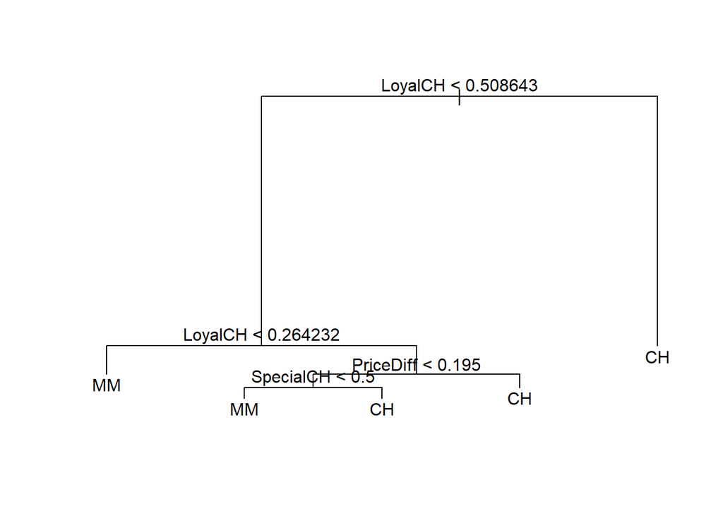

```r
prune.model = prune.misclass(tree.model, best = 5)
plot(prune.model)
text(prune.model, pretty = 0)
```

10. Compare the training error rates between the pruned and unpruned trees. Which is higher?

```r
summary(prune.model)
```

```
##
## Classification tree:
## snip.tree(tree = tree.model, nodes = 3:4)
## Variables actually used in tree construction:
## [1] "LoyalCH"   "PriceDiff" "SpecialCH"
## Number of terminal nodes:  5
## Residual mean deviance:  0.8256 = 656.4 / 795
## Misclassification error rate: 0.165 = 132 / 800
```

*The training error rate for the pruned tree is 16.5%, which is exactly the same as the training error rate observed with the full tree.*

11. Compare the test error rates between the pruned and unpruned trees. Which is higher?

```r
prune.prob = predict(prune.model, newdata = OJ[-train,])
prune.predict = rep('MM', nrow(prune.prob))
prune.predict[prune.prob[, 'CH'] >= .5] = 'CH'
prune.testError = mean(prune.predict != OJ[-train, "Purchase"])

tree.testError
```

```
## [1] 0.2740741
```

```r
prune.testError
```

```
## [1] 0.2259259
```

# Exercise 10

We now use boosting to predict **Salary** in the **Hitters** data set.

1. Remove the observations for which the salary information is unknown and then log-transform the salaries.

```r
Hitters = Hitters[complete.cases(Hitters$Salary),]
Hitters$Salary.log = log(Hitters$Salary)
```

2. Create a training set consisting of the first 200 observations and a test set consisting of the remaining observations.

```r
train = 1:200
```

3. Perform boosting on the training set with 1,000 trees for a range of values of the shrinkage parameter $\lambda$. Produce a plot with different shrinkage values on the *x*-axis and the corresponding training set MSE on the *y*-axis.

```r
# need to gbm library to perform boosting
library(gbm)

# According to the book, typical values are 0.01 or 0.001, so we'll use that as a starting point
shrinkage.values = c(0.01, 0.001, 0.1, 0.005, 0.05)
test.mse = rep(NA, length(shrinkage.values))
training.mse = rep(NA, length(shrinkage.values))

for (index in 1:length(shrinkage.values)){
  boost.model = gbm(Salary.log ~ . - Salary, data = Hitters[train,], distribution = "gaussian", n.trees = 1000, shrinkage = shrinkage.values[index])
  boost.predict = predict(boost.model, newdata = Hitters[-train,], n.trees = 1000)
  test.mse[index] = mean((Hitters[-train, "Salary.log"] - boost.predict)^2)
  training.mse[index] = mean(boost.model$train.error^2)
}
```

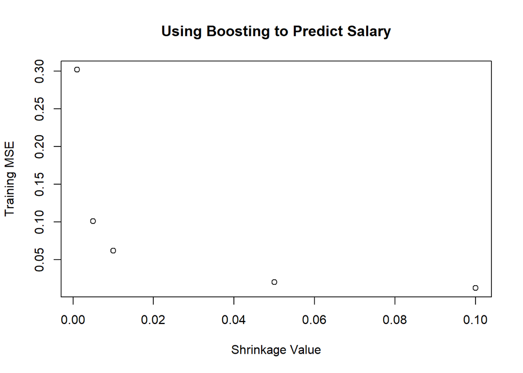

```r
plot(shrinkage.values, training.mse, xlab = 'Shrinkage Value', ylab = 'Training MSE', main = 'Using Boosting to Predict Salary')
```

*And of course, the largest shrinkage value produces the smallest training MSE due to the boosting algorithm, which focusing on minimizing residuals.*

4. Produce a plot with different shrinkage values on the *x*-axis and the corresponding test set MSE on the *y*-axis.

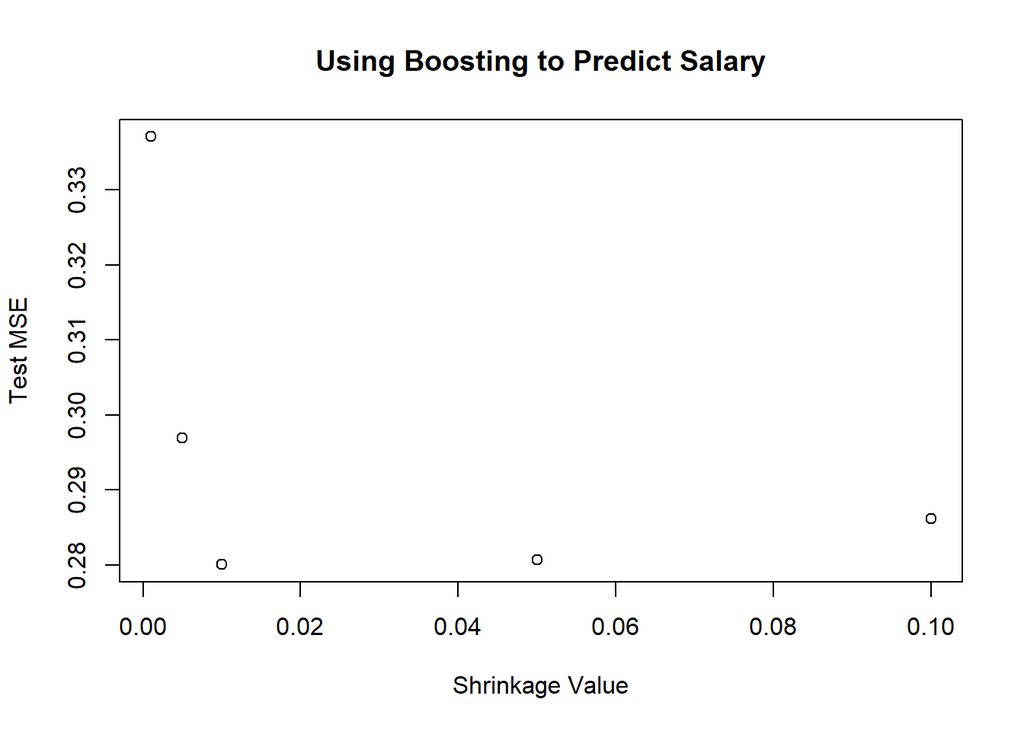

```r
plot(shrinkage.values, test.mse, xlab = 'Shrinkage Value', ylab = 'Test MSE', main = 'Using Boosting to Predict Salary')
```

5. Compare the test MSE of boosting to the test MSE that results from applying two of the regression approaches seen in Chapters 3 and 6.

```r
best.index = which.min(test.mse)
best.shrinkage = shrinkage.values[best.index]
best.mse = test.mse[best.index]
best.shrinkage
```

```
## [1] 0.01
```

```r
best.mse
```

```
## [1] 0.2800611
```

```r
# In Chapter 3, we looked at linear regression, so we'll just do a multiple linear regression on the transformed Salary data
lm.fit = lm(Salary.log ~ . - Salary, data = Hitters, subset = train)
lm.predict = predict(lm.fit, newdata = Hitters[-train,])
lm.mse = mean((Hitters[-train, "Salary.log"] - lm.predict)^2)
lm.mse
```

```
## [1] 0.4917959
```

*The multiple linear regression yields a test MSE of 0.492, which is almost double that of the boosting model.*

```r
# In Chapter 6, we looked at a number of methods, including Best Subset Selection, Ridge Regression, Lasso, PCR, and PLS
# For this exercise, we'll utilize Best Subset Selection, which requires the leaps library
library(leaps)

# Number of predictors; -2 for Salary and Salary.log columns
p = ncol(Hitters) - 2

# We need a matrix to get response predictions from the best subset method, because there is no predict method for regsubsets
test.mat = model.matrix(Salary.log ~ . - Salary, data = Hitters[-train,])

# Find which subset yields the lowest test MSE and roll with that one
regfit.best = regsubsets(Salary.log ~ . - Salary, data = Hitters[train,], nvmax = p)
best.mse = Inf
for (i in 1:p){
  coefi = coef(regfit.best, id = i)
  pred = test.mat[,names(coefi)]%*%coefi
  this.mse = mean((Hitters[-train, "Salary.log"] - pred)^2)
  if (this.mse < best.mse){
    best.mse = this.mse
    best.coef = coefi
  }
}

length(best.coef)
```

```
## [1] 9
```

```r
best.coef
```

```
##   (Intercept)         AtBat          Hits         Walks         Years
##  4.4722395349 -0.0032378215  0.0149552471  0.0105182255  0.0647798866
##         CRuns        CWalks     DivisionW       PutOuts
##  0.0012175332 -0.0010136188 -0.1482230049  0.0005050225
```

```r
best.mse
```

```
## [1] 0.468457
```

*The best subset selection yields an 8 predictor model (not counting the intercept) with a test MSE of 0.468, which is only slightly better than the full multiple linear regression. It is still much worse than the test MSE from boosting.*

6. Which variables appear to be the most important predictors in the boosted model?

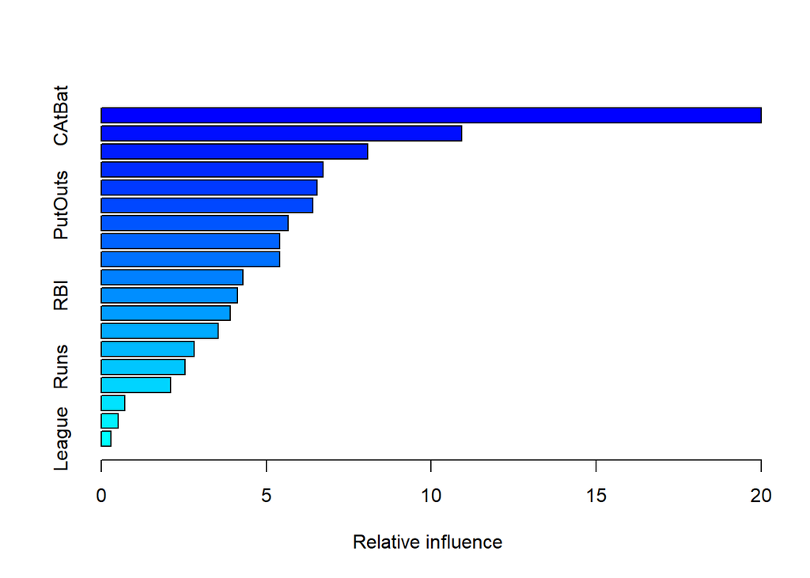

```
##                 var    rel.inf
## CAtBat       CAtBat 20.0016313
## CRuns         CRuns 10.9257398
## CWalks       CWalks  8.0815671
## Years         Years  6.7184333
## CRBI           CRBI  6.5456552
## PutOuts     PutOuts  6.4155962
## CHmRun       CHmRun  5.6683505
## Walks         Walks  5.4062511
## CHits         CHits  5.4028331
## Hits           Hits  4.2915263
## RBI             RBI  4.1287601
## Assists     Assists  3.9069660
## AtBat         AtBat  3.5494994
## HmRun         HmRun  2.8195913
## Runs           Runs  2.5350925
## Errors       Errors  2.0937102
## Division   Division  0.7106661
## NewLeague NewLeague  0.5115559
## League       League  0.2865745
```

```r
summary(boost.model)
```

*In the boosted model, the number of times at bat during a career* (**CAtBat**) *had far and away the greatest relative influence on a player’s salary. The second most influential predictor, the number of runs during a career* (**CRuns**), *had only half as much relative influence on a player’s salary.*

7. Now apply bagging to the training set. What is the test set MSE for this approach?

```r
set.seed(1)
bag.model = randomForest(Salary.log ~ . - Salary, data = Hitters, subset = train, mtry = p, importance = T)
bag.predict = predict(bag.model, newdata = Hitters[-train,])
bag.mse = mean((Hitters[-train, "Salary.log"] - bag.predict)^2)
bag.mse
```

```
## [1] 0.2301184
```

*The bagging approach yields a test MSE of 0.230, which is a bit less than the boost test MSE. Out of all the techniques we applied to this data set, the bagging has yielded the lowest test MSE.*

# Exercise 11

This question uses the **Caravan** data set.

1. Create a training set consisting of the first 1,000 observations and a test set consisting of the remaining observations.

```r
train = 1:1000

# Convert the Purchase response to a factor
Caravan$Purchase.factor = ifelse(Caravan$Purchase == "Yes", 1, 0)
```

2. Fit a boosting model to the training set with **Purchase** as the response and the other variables as predictors. Use 1,000 trees and a shrinkage value of 0.01. Which predictors appear to be the most important?

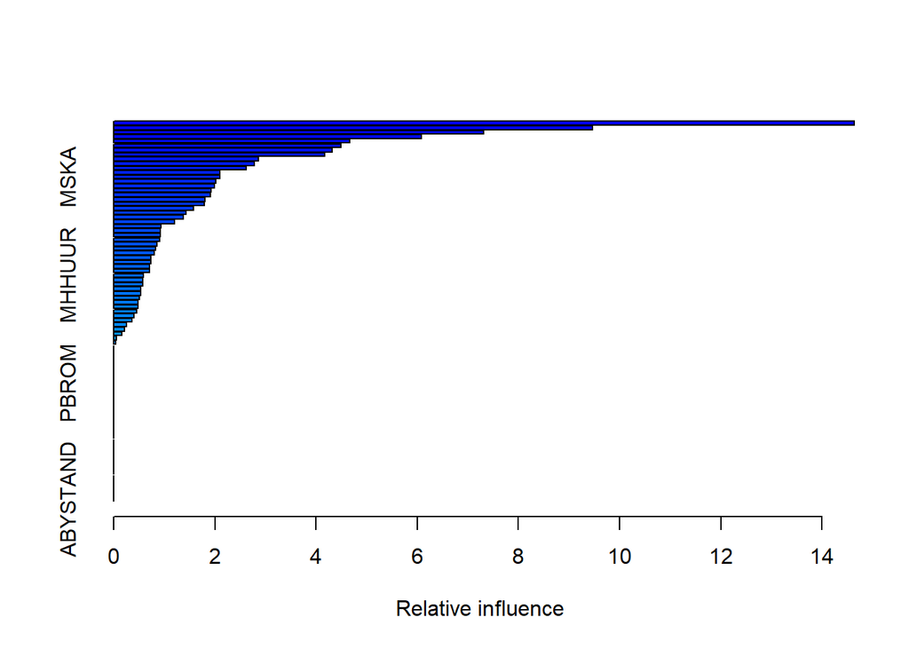

```
##               var     rel.inf
## PPERSAUT PPERSAUT 14.63504779
## MKOOPKLA MKOOPKLA  9.47091649
## MOPLHOOG MOPLHOOG  7.31457416
## MBERMIDD MBERMIDD  6.08651965
## PBRAND     PBRAND  4.66766122
## MGODGE     MGODGE  4.49463264
## ABRAND     ABRAND  4.32427755
## MINK3045 MINK3045  4.17590619
## MOSTYPE   MOSTYPE  2.86402583
## PWAPART   PWAPART  2.78191075
## MAUT1       MAUT1  2.61929152
## MBERARBG MBERARBG  2.10480508
## MSKA         MSKA  2.10185152
## MAUT2       MAUT2  2.02172510
## MSKC         MSKC  1.98684345
## MINKGEM   MINKGEM  1.92122708
## MGODPR     MGODPR  1.91777542
## MBERHOOG MBERHOOG  1.80710618
## MGODOV     MGODOV  1.78693913
## PBYSTAND PBYSTAND  1.57279593
## MSKB1       MSKB1  1.43551401
## MFWEKIND MFWEKIND  1.37264255
## MRELGE     MRELGE  1.20805179
## MOPLMIDD MOPLMIDD  0.93791970
## MINK7512 MINK7512  0.92590720
## MINK4575 MINK4575  0.91745993
## MGODRK     MGODRK  0.90765539
## MFGEKIND MFGEKIND  0.85745374
## MZPART     MZPART  0.82531066
## MRELOV     MRELOV  0.80731252
## MINKM30   MINKM30  0.74126812
## MHKOOP     MHKOOP  0.73690793
## MZFONDS   MZFONDS  0.71638323
## MAUT0       MAUT0  0.71388052
## MHHUUR     MHHUUR  0.59287247
## APERSAUT APERSAUT  0.58056986
## MOSHOOFD MOSHOOFD  0.58029563
## MSKB2       MSKB2  0.53885275
## PLEVEN     PLEVEN  0.53052444
```

[output cut: 31 more lines]

```
## AMOTSCO   AMOTSCO  0.00000000
## AVRAAUT   AVRAAUT  0.00000000
## AAANHANG AAANHANG  0.00000000
## ATRACTOR ATRACTOR  0.00000000
## AWERKT     AWERKT  0.00000000
## ABROM       ABROM  0.00000000
## ALEVEN     ALEVEN  0.00000000
## APERSONG APERSONG  0.00000000
## AGEZONG   AGEZONG  0.00000000
## AWAOREG   AWAOREG  0.00000000
## AZEILPL   AZEILPL  0.00000000
## APLEZIER APLEZIER  0.00000000
## AFIETS     AFIETS  0.00000000
## AINBOED   AINBOED  0.00000000
## ABYSTAND ABYSTAND  0.00000000
```

```r
set.seed(1)
boost.model = gbm(Purchase.factor ~ . - Purchase, data = Caravan[train,], distribution = "bernoulli", n.trees = 1000, shrinkage = 0.01)
summary(boost.model)
```

*There are 85 predictors in this data set, but the* **PPERSAUT** *is deemed to be much more important than the others. The next most important predictors are* **MKOOPKLA** *and* **MOPLHOOG**.

3. Use the boosting model to predict the response on the test data. Predict that a person will make a purchase if the estimated probability of purchase is greater than 20%. Form a confusion matrix. What fraction of the people predicted to make a purchase do in fact make one? How does this compare with the results obtained from applying KNN or logistic regression to this data set?

```r
boost.prob = predict(boost.model, newdata = Caravan[-train,], n.trees = 1000, type = "response")
boost.predict = ifelse(boost.prob > .20, "Yes", "No")
table(boost.predict, Caravan[-train, "Purchase"])
```

```
##
## boost.predict   No  Yes
##           No  4410  256
##           Yes  123   33
```

```r
33 / (123 + 33)
```

```
## [1] 0.2115385
```

*21.15% of people predicted to make a purchase actually do make one.*

```r
# use KNN, which is part of the class library, to predict purchase
library(class)

# Need to set a seed for consistency because knn() uses a random choice to settle ties
set.seed(1)

# the knn function requires the input to be a matrix, which should be standardized
standardized.mat = scale(subset(Caravan, select = -c(Purchase, Purchase.factor)))
train.mat = standardized.mat[train,]
test.mat = standardized.mat[-train,]

# We'll consider a range of K values, from 1 to the sqrt(n), with n being the number of observations in the training set
best.rate = 0
for (k in 1:floor(sqrt(length(train)))){
  knn.pred = knn(train.mat, test.mat, Caravan[train, "Purchase"], k = k)
  this.table = table(knn.pred, Caravan[-train, "Purchase"])
  this.rate = this.table["Yes", "Yes"] / sum(this.table["Yes",])
  if (!is.na(this.rate) & (this.rate > best.rate)){
    best.rate = this.rate
    best.table = this.table
    best.k = k
  }
}

best.table
```

```
##
## knn.pred   No  Yes
##      No  4507  279
##      Yes   26   10
```

```r
best.k
```

```
## [1] 5
```

```r
best.rate
```

```
## [1] 0.2777778
```

*KNN was able correct about 27.78% of the test observations predicted to make a purchase. This percentage was yielded by a KNN with k = 5 and is significantly higher than the boosting model, but there are also much fewer test observations that are predicted to make a purchase. Note that we are not using a 20% probability threshold here; I don’t believe that makes as much sense using KNN in R. You could make a prediction of purchase if more than 20% of the K nearest neighbors are predicted to make a purchase, but I do not believe that is convenient to implement in R, so I won’t.*

```r
# use logistic regression to predict purchase
glm.model = glm(Purchase.factor ~ . - Purchase, data = Caravan, subset = train, family = binomial)
glm.prob = predict(glm.model, newdata = Caravan[-train,], type = "response")
glm.pred = ifelse(glm.prob > .20, "Yes", "No")
table(glm.pred, Caravan[-train, "Purchase"])
```

```
##
## glm.pred   No  Yes
##      No  4183  231
##      Yes  350   58
```

```r
58 / (350 + 58)
```

```
## [1] 0.1421569
```

*Only 14.22% of the test observations predicted to make a purchase actually did. This percentage is much lower than boosting. It did actually predict much more of the test observations to make a purchase, and we were able to easily implement the 20% threshold in the logistic regression.*

# Exercise 12

Apply boosting, bagging, and random forests to a data set of your choice. Be sure to fit the models on a training set and to evaluate their performance on a test set. How accurate are the results compared to simple methods like linear or logistic regression? Which of these approaches yields the best performance?

```r
# We'll work with the airquality data set from the datasets package
library(datasets)

# drop any NaNs
airquality = airquality[complete.cases(airquality),]
names(airquality)
```

```
## [1] "Ozone"   "Solar.R" "Wind"    "Temp"    "Month"   "Day"
```

```r
dim(airquality)
```

```
## [1] 111   6
```

```r
# We'll create models to predict the maximum daily temperature in degrees Farenheit (Temp)

# Number of observations
n = nrow(airquality)

# Number of predictors
p = ncol(airquality) - 1

# First, split the data into a training set and a test set
set.seed(1)
train = sample(n, n/2)

# Create a data frame to store test MSE results for each model
df = data.frame(model.name = rep(NA, 5), test.mse = rep(NA, 5))
```

```r
# Create the boosting model
df[1, "model.name"] = "boosting"
boost.model = gbm(Temp ~ ., data = airquality[train,], distribution = "gaussian", n.trees = 1000)
boost.predict = predict(boost.model, newdata = airquality[-train,], n.trees = 1000)
boost.mse = mean((airquality[-train, "Temp"] - boost.predict)^2)
df[1, "test.mse"] = boost.mse
```

```r
# Create the bagging model
set.seed(1)
df[2, "model.name"] = "bagging"
bag.model = randomForest(Temp ~ ., data = airquality, subset = train, mtry = p, importance = T)
bag.predict = predict(bag.model, newdata = airquality[-train,])
bag.mse = mean((airquality[-train, "Temp"] - bag.predict)^2)
df[2, "test.mse"] = bag.mse
```

```r
# Create the random forests model
set.seed(1)
df[3, "model.name"] = "random forests"
rf.model = randomForest(Temp ~ ., data = airquality, subset = train, mtry = p/2, importance = T)
rf.predict = predict(rf.model, newdata = airquality[-train,])
rf.mse = mean((airquality[-train, "Temp"] - rf.predict)^2)
df[3, "test.mse"] = rf.mse
```

```r
# Create the multiple linear regression model
df[4, "model.name"] = "linear regression"
lm.model = lm(Temp ~ ., data = airquality, subset = train)
lm.predict = predict(lm.model, newdata = airquality[-train,])
lm.mse = mean((airquality[-train, "Temp"] - lm.predict)^2)
df[4, "test.mse"] = lm.mse
```

```r
# Logistic regression is specific to qualitative response variables, but we can perform a log transformation on Temp and fit a linear regression on that
df[5, "model.name"] = "log transform regression"
log.model = lm(log(Temp) ~ ., data = airquality, subset = train)
log.predict = exp(predict(log.model, newdata = airquality[-train,]))
log.mse = mean((airquality[-train, "Temp"] - log.predict)^2)
df[5, "test.mse"] = log.mse
```

```r
# Show the results
df
```

```
##                 model.name test.mse
## 1                 boosting 64.10107
## 2                  bagging 40.37541
## 3           random forests 36.05172
## 4        linear regression 51.59265
## 5 log transform regression 55.33704
```

*We can see that the random forests model performed better than any of the other models. It had a much lower test MSE than the linear regression and the log transform regression models. The bagging model had a test MSE which was very close to that of the random forests model. The boosting model performed very poorly on this data set compared to the other models.*